# Assignment2

## PROG8245 Assignment 2: (Total Marks 110)

## Start on 14th of October- Due on 1st of November

- Name:Jun He
- ID:8903073
- Kindly note that this assignment is to be solved by yourself, without the use of AI and chatbots.
- If chatbot usage is detected, the penalty that is discussed in Week 1 slides will apply.
- Each code block will have a Todo comment which explains the functionality, expected input, and expected output of the function.
- There are 10 marks in this assignment for commenting and code readability.

### Part 1: Visualizations (34)

**NOTE:** Each question for plot in the visualization section is expected to be represented in **one** graph, using the library of your choice:

#### **Question 1**

Using the following dataset: https://raw.githubusercontent.com/mwaskom/seaborn-data/master/penguins.csv choose the most convenient graph to show the following: (18 Marks)

**1. The relationship between the penguin's bill length and bill depth for each species.** (5 marks)

```python
# import packages needed
import seaborn as sns
import matplotlib.pyplot as plt
import pandas as pd
import numpy as np
from sklearn.preprocessing import StandardScaler
from scipy import stats
```

```
  species     island  bill_length_mm  bill_depth_mm  flipper_length_mm  \
0  Adelie  Torgersen            39.1           18.7              181.0

   body_mass_g   sex
0       3750.0  MALE
```

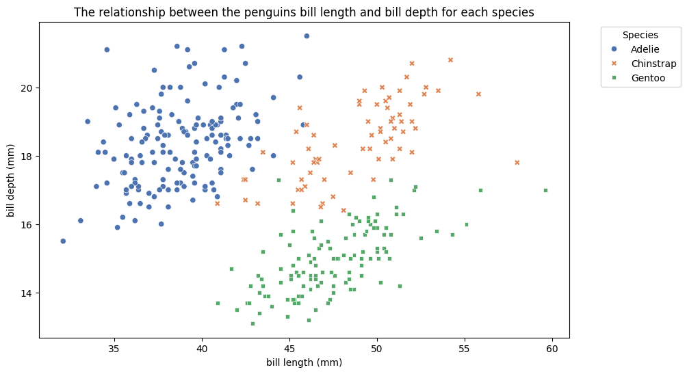

```python
## TODO: Check your attributes, make a graph using Matplotlib or Seaborn to show the relationship needed

# load data
url = "https://raw.githubusercontent.com/mwaskom/seaborn-data/master/penguins.csv"
penguins = pd.read_csv(url)
# display dataset structure
print(penguins.head(1))

# create the scatter plot
plt.figure(figsize=(10,6))
sns.scatterplot(data=penguins, x='bill_length_mm', y='bill_depth_mm', hue='species', style='species', palette='deep')
plt.title('The relationship between the penguins bill length and bill depth for each species')
plt.xlabel('bill length (mm)')
plt.ylabel('bill depth (mm)')
# adjust the legend
plt.legend(title = 'Species', bbox_to_anchor = (1.05, 1), loc='upper left')
plt.show()
```

**What do you observe from the graph?** (2 marks)

**Why did you choose this type of graph?** (2 marks)

Your answer here:

- The scatter plot more intuitively shows the relationship between bill length and bill depth of penguins, and we can easily see its correlation and distribution.
- Each dot represents an entity, each color represents a species, clearly showing the characteristics of the two-dimensional data

**2. Suitable graph of the mean BMI (BMI not body_mass; BMI Equation is: weight_in_kg/height^2) of female and male penguins. (Assume the height is the flipper length)** (5 marks)

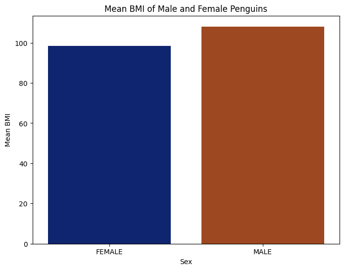

```python
#Your answer here

# Removes rows with missing values in the specified columns(body_mass_g', 'flipper_length_mm', 'sex')
# in case of avoiding NaN data and other errors
penguins = penguins.dropna(subset=['body_mass_g', 'flipper_length_mm', 'sex'])

# Calculate BMI
#firstly, change the unit g--kg   mm-m
penguins['weight_kg'] = penguins['body_mass_g'] / 1000  # Convert grams to kilograms
penguins['height_m'] = penguins['flipper_length_mm'] / 1000  # Convert mm to meters
# BMI = weight_in_kg/height^2
penguins['BMI'] = penguins['weight_kg'] / (penguins['height_m'] ** 2)

# Calculate mean BMI for male and famale
# group by sex and then calculate mean BMI
# reset_index（）reset dataframe index
mean_bmi = penguins.groupby('sex')['BMI'].mean().reset_index()

# Plot the mean BMI by sex
# create the bar plot
plt.figure(figsize=(8, 6))
sns.barplot(data=mean_bmi, x='sex', y='BMI', palette='dark')

# Set plot title and labels
plt.title('Mean BMI of Male and Female Penguins')
plt.xlabel('Sex')
plt.ylabel('Mean BMI')

plt.show()
```

**What do you observe from the graph?** (2 marks)

Your answer here:

**Why did you choose this type of graph?** (2 marks)

Your answer here:

- A bar plot is a common data visualization chart used to display comparisons between different categories. Each category is represented by a rectangular bar, with the height or length of the bar indicating the value of that category.
- In this case, we can see that we need to know the average BMI condition of femal and male, comparing these two genders, it is easier to know average values.

#### **Question 2**

You can find the csv file that contains the museum visitors data here: ./CSVs/museum_visitors.csv (8 marks)

Review the data by taking a look at a few of the rows.

```python
# Your solution here
visitors = pd.read_csv('museum_visitors.csv')
print(visitors.head(5))
```

```
         Date  Avila Adobe  Firehouse Museum  Chinese American Museum  \
0  2014-01-01        24778              4486                     1581
1  2014-02-01        18976              4172                     1785
2  2014-03-01        25231              7082                     3229
3  2014-04-01        26989              6756                     2129
4  2014-05-01        36883             10858                     3676

   America Tropical Interpretive Center
0                                  6602
1                                  5029
2                                  8129
3                                  2824
4                                 10694
```

Convince the museum board

The Firehouse Museum claims they ran an event in 2014 that brought an incredible number of visitors, and that they should get extra budget to run a similar event again. The other museums think these types of events aren't that important, and budgets should be split purely based on recent visitors on an average day.

To show the museum board how the event compared to regular traffic at each museum, create a suitable chart that shows how the number of visitors to each museum evolved over time. (4 marks)

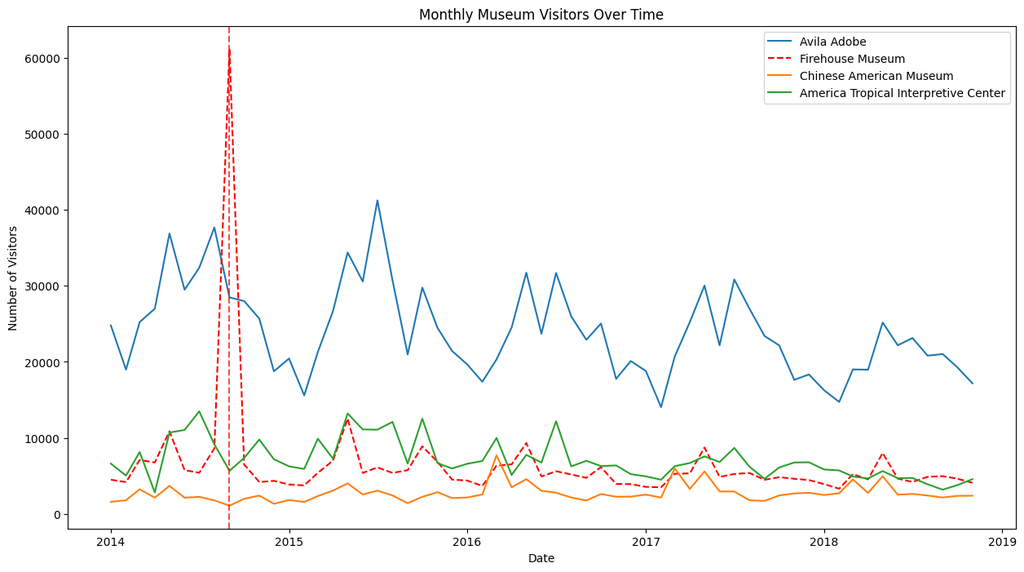

```python
#Your solution here
# because shows how the number of visitors to each museum evolved over time
# line chart can fit this situation.
# firstly set the date as index
visitors['Date'] = pd.to_datetime(visitors['Date'])

visitors.set_index('Date', inplace=True)
# visitors['Year-Month'] = visitors['Date'].dt.strftime('%Y-%m')

# plot the numbers of visitor over time
plt.figure(figsize=(15,8))
plt.plot(visitors.index, visitors['Avila Adobe'], label='Avila Adobe')
plt.plot(visitors.index, visitors['Firehouse Museum'], label='Firehouse Museum', color='red', linestyle='--')  # Highlight Firehouse Museum
plt.plot(visitors.index, visitors['Chinese American Museum'], label='Chinese American Museum')
plt.plot(visitors.index, visitors['America Tropical Interpretive Center'], label='America Tropical Interpretive Center')

# Add labels and title
plt.xlabel('Date')
plt.ylabel('Number of Visitors')
plt.title('Monthly Museum Visitors Over Time')
plt.legend(loc='upper right')

# Highlighting the Firehouse Museum event
firehouse_peak = visitors['Firehouse Museum'].idxmax()
plt.axvline(firehouse_peak, color='red', linestyle='--', alpha=0.7, label='Firehouse Museum Event')

plt.show()
```

What did you observe from the graph? (2 marks)

Your answer here

- Overall, each line represents the monthly visitor count for a different museum, which will show how visitation changed over time, we can see most of time they are keep a normal level and show a cyclical trend.
- The Firehouse Museum's Special Event (September 2014) spike spike over 60000 visitors; however, it only lasted one month, and then returned to normal levels.
- Avila Adobe (blue line) has the highest regular visitor number; Chinese American Museum (orange) has the lowest level between 2,000 and 4,000.
- It looks like the number of visitors are influced by season, most museums show higher attendance during spring/summer months.

Why did you choose this type of graph? (2 marks)

You answer here

- Firstly, this situation fit time series, it can show the numbers changed over time, we can easily spot any spikes or dips in the graph.
- In addition, for each museum has single line, we can compare the numbers of visitor of multiple museums on the same graph.
- If we want to highlight some special events, we can use different style or color to mark it.
- Finally, line chart is an essential way to show the data that changes over time, and the data is allowed to be continuous.

#### **Question 3**

Using the file in ./CSVs/gas_prices.csv  
Use a suitable plot/graph that will show the relationship between the average gas price for each country over all years (vs others). (8 marks)

First, review the data by taking a look at a few of the rows.

```python
# load data
gp_ds = pd.read_csv('gas_prices.csv')
print(gp_ds.head(5))
```

```
   Year  Australia  Canada  France  Germany  Italy  Japan  Mexico  \
0  1990        NaN    1.87    3.63     2.65   4.59   3.16    1.00
1  1991       1.96    1.92    3.45     2.90   4.50   3.46    1.30
2  1992       1.89    1.73    3.56     3.27   4.53   3.58    1.50
3  1993       1.73    1.57    3.41     3.07   3.68   4.16    1.56
4  1994       1.84    1.45    3.59     3.52   3.70   4.36    1.48

   South Korea    UK   USA
0         2.05  2.82  1.16
1         2.49  3.01  1.14
2         2.65  3.06  1.13
3         2.88  2.84  1.11
4         2.87  2.99  1.11
```

Then Plot using the most suitable plot on your opinion (5 marks)

```
   Australia  Canada  France  Germany  Italy  Japan  Mexico  South Korea  \
0       0.00    1.87    3.63     2.65   4.59   3.16    1.00         2.05
1       1.96    1.92    3.45     2.90   4.50   3.46    1.30         2.49
2       1.89    1.73    3.56     3.27   4.53   3.58    1.50         2.65
3       1.73    1.57    3.41     3.07   3.68   4.16    1.56         2.88
4       1.84    1.45    3.59     3.52   3.70   4.36    1.48         2.87

     UK   USA
0  2.82  1.16
1  3.01  1.14
2  3.06  1.13
3  2.84  1.11
4  2.99  1.11
```

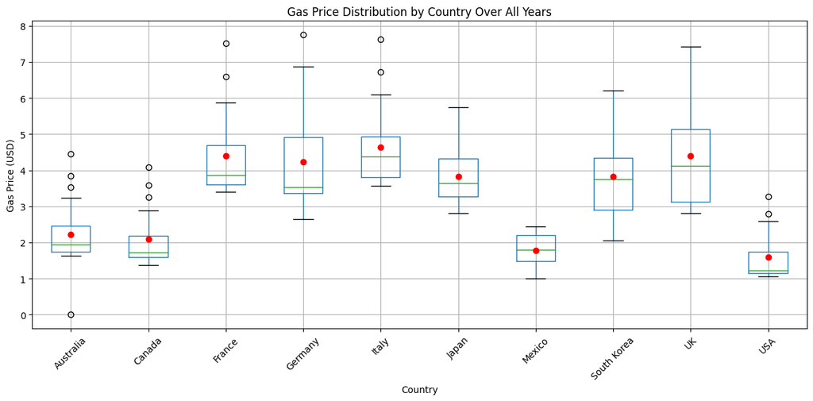

```python
## Your solution here

# remove "Year" column，we only calculate the price all the year for each country
gp_ds = gp_ds.drop(columns=['Year'])
# process outlers, like NaN to 0
gp_ds = gp_ds.fillna(0)

# check data again
print(gp_ds.head(5))

# calculate the mean for each country
mean_prices = gp_ds.mean()

# ploting
plt.figure(figsize=(15, 6))
box = gp_ds.boxplot()

# Add mean prices as points on the boxplot
for i, mean in enumerate(mean_prices):
    plt.scatter(i + 1, mean, color='red', label='Mean' if i == 0 else "", zorder=5)

# add label and title
plt.xlabel('Country')
plt.ylabel('Gas Price (USD)')
plt.title('Gas Price Distribution by Country Over All Years')
plt.xticks(rotation=45)
plt.show()
```

Is there anything interesting observed from the plot/graph? (1 mark)

Why did you choose this type of graph? (2 marks)

You answer here

- In fact, we can use pie chart and bar chart, but the box plot can give us a clear understanding of gas price distributions from different countries.
- It also shows us important trends, variability, and potential outliers. We needn't to calculate lots of metrics, there are Median values, Quartile ranges, Overall price spread and Outliers and extreme values, so it is easier for us to see the trend of gas price.

### Part 2: Data Tidying and Preprocessing (24)

#### **Question 4:** (12)

**Tuberculosis Dataset** This dataset outlines the number of tuberculosis patients in different countries in the year 2000.  
Dataset name: tb-raw.csv  
A few notes on the raw data set:

- The columns starting with "m" or "f" contain multiple variables:
  - Sex ("m" or "f")
  - Age Group ("0-14","15-24", "25-34", "45-54", "55-64", "65", "unknown")
- Mixture of 0s and missing values("NaN"). This is due to the data collection process and the **distinction** is important for this dataset.
- Task: Apply Data Tidying techniques to get a tidier dataset with more representive columns, please do it step-by-step and explain each step you are doing.

(12 Marks)

```python
## TODO: Apply your Data Tidying Technique here
# firstly load the data
patient_ds = pd.read_csv('tb-raw.csv')
print(patient_ds.head(5))
```

```
  country  year  m014  m1524  m2534  m3544  m4554  m5564   m65  mu  f014
0      AD  2000   0.0    0.0    1.0    0.0      0      0   0.0 NaN   NaN
1      AE  2000   2.0    4.0    4.0    6.0      5     12  10.0 NaN   3.0
2      AF  2000  52.0  228.0  183.0  149.0    129     94  80.0 NaN  93.0
3      AG  2000   0.0    0.0    0.0    0.0      0      0   1.0 NaN   1.0
4      AL  2000   2.0   19.0   21.0   14.0     24     19  16.0 NaN   3.0
```

```python
# Try to make the column headers represent a variable not a value. For that, use the `melt` function.
# the year all is 2000, we can remove this column
patient_ds = patient_ds.drop(columns=['year'])

# basicly-----deal with missing value
# Replace NaN with 0
patient_ds.fillna(0, inplace=True)

# define a function to convert age range
def convert_age_range(age_range):
    if age_range == '65':
        return '65+'
    elif age_range == 'unknown':
        return 'unknown'
    else:
        return f"{age_range[:2]}-{age_range[2:]}"

# Reshape the dataframe from wide to long format
df_melted = patient_ds.melt(id_vars=['country'], var_name='variable', value_name='value')
df_melted['sex'] = df_melted['variable'].str[0]
df_melted['age_range'] = df_melted['variable'].str[1:].apply(convert_age_range)
df_melted = df_melted.drop(columns=['variable'])
# print(df_melted)

# # firstly------ Summarize the total number of tuberculosis patients by country
# patient_ds['total_cases'] = patient_ds.loc[:, 'm014':'mu'].sum(axis=1) + patient_ds.loc[:, 'f014'].fillna(0)
# # Display the summary
# print(patient_ds[['country', 'total_cases']])

# # Create separate DataFrames for male and female cases
# male_columns = ['m014', 'm1524', 'm2534', 'm3544', 'm4554', 'm5564', 'm65', 'mu']
# female_columns = ['f014']

# Group by ‘country’, ‘sex’, and ‘age_range’ and summarize the patient count
patient_clean = df_melted.groupby(['country', 'sex', 'age_range'])['value'].sum().reset_index()

# Rename the 'value' column to 'patient_count'
patient_clean.columns = ['country', 'sex', 'age_range', 'patient_count']

print(patient_clean)

# summary = patient_clean.groupby(['country', 'sex', 'age_range'])['value'].sum().reset_index()
# summary.columns = ['country', 'sex', 'age_range', 'patient_count']

# print(summary)

# # secondly-------Sum the male cases by age group
# male_cases = patient_ds[male_columns].sum()
# # Sum the female cases
# female_cases = patient_ds[female_columns].sum()
# print(male_cases)
# print(female_cases)
```

```
   country sex age_range  patient_count
0       AD   f      01-4            0.0
1       AD   m      01-4            0.0
2       AD   m     15-24            0.0
3       AD   m     25-34            1.0
4       AD   m     35-44            0.0
..     ...  ..       ...            ...
85      AS   m     35-44            0.0
86      AS   m     45-54            1.0
87      AS   m     55-64            1.0
88      AS   m       65+            0.0
89      AS   m        u-            0.0

[90 rows x 4 columns]
```

#### Question 5: (12)

Using Boston House pricing dataset, apply outlier detection techniques discussed in class to detect outliers. Use different techniques and comment your code.  
You need to check how to load the dataset correctly!

1. You should include some Visualization techniques
2. You should include some statistical approaches
3. You should analyze your attributes using **Univariant and multivariant** outlier detection techniques.
4. Choose one or more of your outlier detection techniques and remove outliers

```
             CRIM          ZN       INDUS        CHAS         NOX          RM  \
count  506.000000  506.000000  506.000000  506.000000  506.000000  506.000000
mean     3.613524   11.363636   11.136779    0.069170    0.554695    6.284634
std      8.601545   23.322453    6.860353    0.253994    0.115878    0.702617
min      0.006320    0.000000    0.460000    0.000000    0.385000    3.561000
25%      0.082045    0.000000    5.190000    0.000000    0.449000    5.885500
50%      0.256510    0.000000    9.690000    0.000000    0.538000    6.208500
75%      3.677083   12.500000   18.100000    0.000000    0.624000    6.623500
max     88.976200  100.000000   27.740000    1.000000    0.871000    8.780000

              AGE         DIS         RAD         TAX     PTRATIO           B  \
count  506.000000  506.000000  506.000000  506.000000  506.000000  506.000000
mean    68.574901    3.795043    9.549407  408.237154   18.455534  356.674032
std     28.148861    2.105710    8.707259  168.537116    2.164946   91.294864
min      2.900000    1.129600    1.000000  187.000000   12.600000    0.320000
25%     45.025000    2.100175    4.000000  279.000000   17.400000  375.377500
50%     77.500000    3.207450    5.000000  330.000000   19.050000  391.440000
75%     94.075000    5.188425   24.000000  666.000000   20.200000  396.225000
max    100.000000   12.126500   24.000000  711.000000   22.000000  396.900000

            LSTAT        MEDV
count  506.000000  506.000000
mean    12.653063   22.532806
std      7.141062    9.197104
min      1.730000    5.000000
25%      6.950000   17.025000
50%     11.360000   21.200000
75%     16.955000   25.000000
max     37.970000   50.000000
```

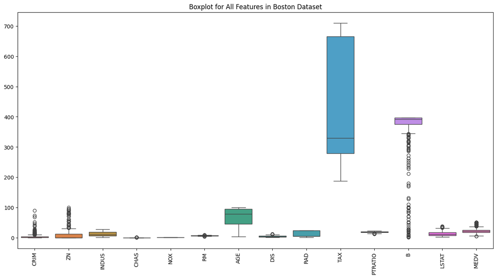

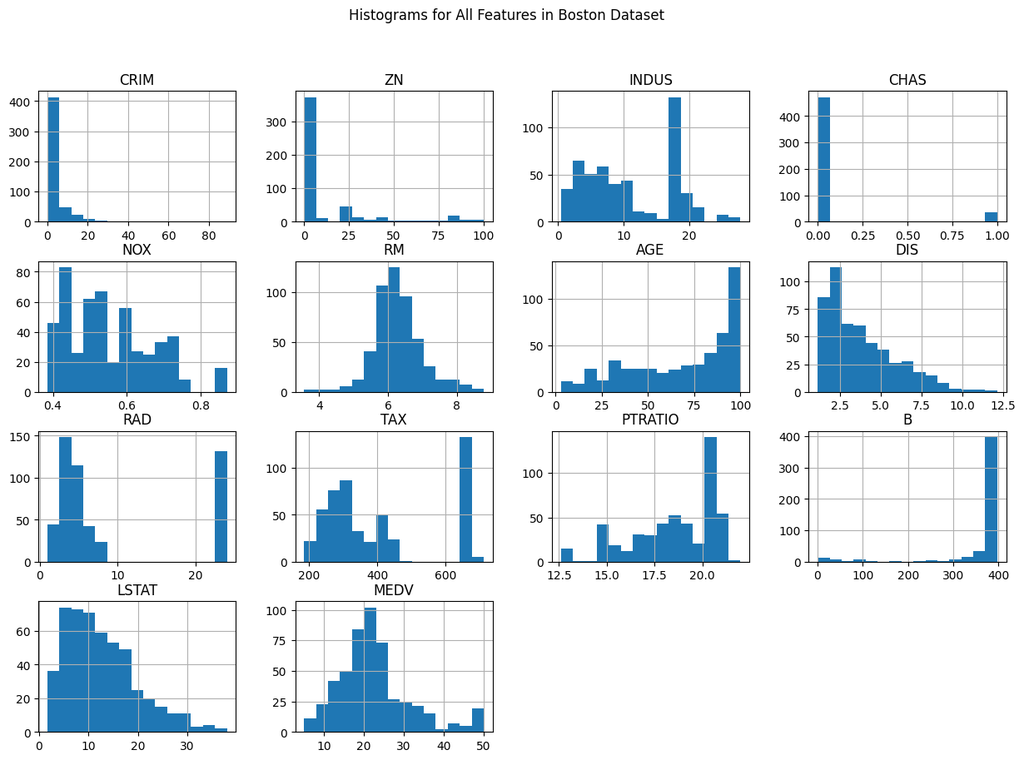

```
Outliers count for each attribute (generally Z-Score > 3):
CRIM        8
ZN         14
INDUS       0
CHAS       35
NOX         0
RM          8
AGE         0
DIS         5
RAD         0
TAX         0
PTRATIO     0
B          25
LSTAT       5
MEDV        0
dtype: int64
Local Outlier Factor Outliers Detected totally: 26
Original Dataset Shape: (506, 14)
Dataset Shape After Outlier Removal: (415, 14)
```

```python
# Importing
data_url = "http://lib.stat.cmu.edu/datasets/boston"
#  ---------------------------1. load the dataset
original_df = pd.read_csv(data_url, sep="\s+", skiprows = 22, header=None)
# print(original_df)

# Combining two parts into one DataFrame
# The dataset is divided into two parts in the original file, so we need to concatenate them correctly
# every two rows as a single data entry,first row having 11 columns and the second having 3

#raw_df.values[::2, :]takes every other row  captures the first 11 columns
#raw_df.values[1::2, :3]captures the last 3 columns.
# horizontally stacks these arrays, giving us one full row of 16 columns per data entry.
data = np.hstack([original_df.values[::2, :], original_df.values[1::2, :3]])
columns = [
    "CRIM", "ZN", "INDUS", "CHAS", "NOX", "RM", "AGE", "DIS", "RAD", "TAX",
    "PTRATIO", "B", "LSTAT", "MEDV"
]
df = pd.DataFrame(data, columns=columns)
# --------------------------------------show some statistic data
print(df.describe())

# ----------------------------2.Visualizing
# we can use boxplot and histograms to see some outliers
# Boxplot for each column
plt.figure(figsize=(16, 8))
sns.boxplot(data=df)
plt.title("Boxplot for All Features in Boston Dataset")
plt.xticks(rotation=90)
plt.show()

# Histograms for each feature
df.hist(bins=15, figsize=(15, 10), layout=(4, 4))
plt.suptitle("Histograms for All Features in Boston Dataset")
plt.show()

# ------------------------------3.outliers detection
# Univariate Outlier Detection Using Z-Score
z_scores = np.abs(stats.zscore(df))
outliers_zscore = (z_scores > 3)
print("Outliers count for each attribute (generally Z-Score > 3):")
print(pd.Series(outliers_zscore.sum(axis=0)))

#Multivariate Outlier Detection Using Mahalanobis Distance
# we use LocalOutlierFactor to calculates the density of each point relative to its neighbors
from sklearn.neighbors import LocalOutlierFactor
# Use Local Outlier Factor for multivariate outlier detection
lof = LocalOutlierFactor(n_neighbors=20, contamination=0.05)  # Assuming 5% of data are outliers
outliers_lof = lof.fit_predict(df)  # -1 represents an outlier
# Count LOF outliers
lof_outliers = (outliers_lof == -1)
print(f"Local Outlier Factor Outliers Detected totally: {lof_outliers.sum()}")


## Based on the results, choose a method to remove outliers. Here we’ll remove outliers using Z-score.
# -----------------------4.Removing rows with any Z-score > 3
df_no_outliers = df[(z_scores < 3).all(axis=1)]

# Comparison before and after removing outliers
print("Original Dataset Shape:", df.shape)
print("Dataset Shape After Outlier Removal:", df_no_outliers.shape)
```

### Part 3: Feature Engineering (17)

#### Question 6- Feature Engineering - Attribute Correlation (17)

- Load the file income_data.csv, inspect the columns.
- Determine if race and education features have a statistical relationship.
- Explain and conclude your findings (7 till here)
- Inspect the dataset carefully and create an Indicator Feature (0/1) --(3)
- Inspect the dataset carefully and create an Interaction Feature (Additional feature engineered from your dataset)-- (3)

**The features you create must be resonable, please add an explanation to explain why did you chose those features** (2 for each explanation -> 4)

```python
## TODO: Start Question 6 code here
# load the data
df_income = pd.read_csv('income_data.csv')
print(df_income.columns)
print(df_income.head(1))
print(df_income.describe)
```

```
Index(['age', 'workclass', 'fnlwgt', 'education', 'educational-num',
       'marital-status', 'occupation', 'relationship', 'race', 'gender',
       'capital-gain', 'capital-loss', 'hours-per-week', 'native-country',
       'income'],
      dtype='object')
   age workclass  fnlwgt education  educational-num marital-status  \
0   25   Private  226802      11th                7  Never-married

          occupation relationship   race gender  capital-gain  capital-loss  \
0  Machine-op-inspct    Own-child  Black   Male             0             0

   hours-per-week native-country income
0              40  United-States  <=50K
<bound method NDFrame.describe of        age     workclass  fnlwgt     education  educational-num  \
0       25       Private  226802          11th                7
1       38       Private   89814       HS-grad                9
2       28     Local-gov  336951    Assoc-acdm               12
3       44       Private  160323  Some-college               10
4       18             ?  103497  Some-college               10
...    ...           ...     ...           ...              ...
48837   27       Private  257302    Assoc-acdm               12
48838   40       Private  154374       HS-grad                9
48839   58       Private  151910       HS-grad                9
48840   22       Private  201490       HS-grad                9
48841   52  Self-emp-inc  287927       HS-grad                9

           marital-status         occupation relationship   race  gender  \
0           Never-married  Machine-op-inspct    Own-child  Black    Male
1      Married-civ-spouse    Farming-fishing      Husband  White    Male
2      Married-civ-spouse    Protective-serv      Husband  White    Male
3      Married-civ-spouse  Machine-op-inspct      Husband  Black    Male
4           Never-married                  ?    Own-child  White  Female
...                   ...                ...          ...    ...     ...
48837  Married-civ-spouse       Tech-support         Wife  White  Female
48838  Married-civ-spouse  Machine-op-inspct      Husband  White    Male
48839             Widowed       Adm-clerical    Unmarried  White  Female
48840       Never-married       Adm-clerical    Own-child  White    Male
48841  Married-civ-spouse    Exec-managerial         Wife  White  Female

       capital-gain  capital-loss  hours-per-week native-country income
0                 0             0              40  United-States  <=50K
1                 0             0              50  United-States  <=50K
2                 0             0              40  United-States   >50K
3              7688             0              40  United-States   >50K
4                 0             0              30  United-States  <=50K
...             ...           ...             ...            ...    ...
48837             0             0              38  United-States  <=50K
48838             0             0              40  United-States   >50K
48839             0             0              40  United-States  <=50K
48840             0             0              20  United-States  <=50K
48841         15024             0              40  United-States   >50K

[48842 rows x 15 columns]>
```

```python
# Determine if Race and Education Have a Statistical Relationship------Chi-Square test is suitable for categorical
from scipy.stats import chi2_contingency

# Create a  table for race and education
re_table = pd.crosstab(df_income['race'], df_income['education'])
print(re_table)

# Perform the Chi-Square test
chi2, p_value, dof, expected = chi2_contingency(re_table)

# Print the results
print("Chi-Square Test Statistic:", chi2)
print("p-value:", p_value)
```

```
education           10th  11th  12th  1st-4th  5th-6th  7th-8th  9th  \
race
Amer-Indian-Eskimo    22    26     5        4        2       10    9
Asian-Pac-Islander    16    27    15       10       28       14   10
Black                182   252   105       24       41       90  111
Other                 11    22    17       13       23       23   15
White               1158  1485   515      196      415      818  611

education           Assoc-acdm  Assoc-voc  Bachelors  Doctorate  HS-grad  \
race
Amer-Indian-Eskimo          13         31         29          3      176
Asian-Pac-Islander          49         53        408         46      336
Black                      161        165        504         16     1780
Other                       10          9         50          3      105
White                     1368       1803       7034        526    13387

education           Masters  Preschool  Prof-school  Some-college
race
Amer-Indian-Eskimo       13          1            2           124
Asian-Pac-Islander      140          7           58           302
Black                   143         12           21          1078
Other                    13          2            5            85
White                  2348         61          748          9289
Chi-Square Test Statistic: 1040.6622432490267
p-value: 7.472985630264855e-179
```

### Findings:

The Chi-Square Test Statistic of 1040.66 with a p-value of 7.47e-179 (essentially 0) indicates a very strong statistical relationship between the race and education features.

1. First I chose Chi-Square Test, because it is suitable for categorical
2. Chi-Square Test Statistic (1040.66) is high shows a significant difference between the race and education.
3. p-value (7.47e-179) is much smaller than 0.05 , we can reject the null hypothesis of independence. This means that race and education have a statistically significant association in this dataset.

```python
# 3. Create an Indicator Feature
# Create an indicator feature for income level
df_income['high_income'] = df_income['income'].apply(lambda x: 1 if x == '>50K' else 0)
print(df_income[['income', 'high_income']].head())

# we can see education condition
df_income['high_education'] = df_income['education'].apply(lambda x: 1 if x in ['Bachelors', 'Masters', 'Doctorate'] else 0)
print(df_income[['education', 'high_income']].head())
```

```
  income  high_income
0  <=50K            0
1  <=50K            0
2   >50K            1
3   >50K            1
4  <=50K            0
      education  high_income
0          11th            0
1       HS-grad            0
2    Assoc-acdm            1
3  Some-college            1
4  Some-college            0
```

### Findings

The results told me that whether an individual’s income exceeds $50K (1) or not (0). This indicator can be useful in classification models to predict income level based on other features.

```python
# Create an Interaction Feature
# Create an interaction feature for educational level and hours worked per week
df_income['education_hours_interaction'] = df_income['educational-num'] * df_income['hours-per-week']
print(df_income[['educational-num', 'hours-per-week', 'education_hours_interaction']].head())
```

```
   educational-num  hours-per-week  education_hours_interaction
0                7              40                          280
1                9              50                          450
2               12              40                          480
3               10              40                          400
4               10              30                          300
```

### Findings

From the Interaction Feature of education hours, maybe we can predict there is a correlation between income and education.

### Part 4: Challenging Preprocessing Problems

#### Question 7: Implementing the Local Outlier Factor (LOF) Function (25)

- Local outlier factor is a function that labels outlier based on 2 predefined parameters, the first one is t **k** for k-Nearest-Neighbours. The second one is the threshold of outliers which could be set arbitrary. However, in this coding task you are required to BOX-PLOTS to determine the threshold for the local outlier factor and label your outliers.
- You are expected to implement different functions to reach the target which will be defined below.

```python
def calculate_point_to_point_distance(point_a, point_b, distance_approach="Euclidean"):
    ## TODO: This function takes as an input two points (where each point is a pair of (x,y)) and returns the distance between the points.
    ## The distance is calculate based on given distance_approach
    ## You need to handle the Euclidean and Manhattan Distance Approaches in your code
    if distance_approach == "Euclidean":#Euclidean
        return np.sqrt((point_a[0] - point_b[0])**2 + (point_a[1] - point_b[1])**2)
    elif distance_approach == "Manhattan":# Manhattan
        return abs(point_a[0] - point_b[0]) + abs(point_a[1] - point_b[1])
    else: # others give error msg
        raise ValueError("Unsupported distance approach")


# helper functions start----------------------------------------------------
# 1. Find 𝐾-nearest neighbors and calculate Nd
def k_nearest_neighbors(point, list_of_points, K, distance_approach="Euclidean"):
    distances = [(other_point, calculate_point_to_point_distance(point, other_point, distance_approach))
                 for other_point in list_of_points if other_point != point]
    distances.sort(key=lambda x: x[1])  # Sort by distance

    # K-nearest neighbors and the distance to the K-th neighbor (Nd)
    neighbors = [d[0] for d in distances[:K]]
    Nd = distances[K-1][1]  # Distance to the K-th nearest neighbor
    return neighbors, Nd

# 2. Calculate ReachDistance(x,p)=max(Nd_x, Distance(x,p))
def reachability_distance(point, neighbor, list_of_points, K, distance_approach="Euclidean"):
    _, Nd_neighbor = k_nearest_neighbors(neighbor, list_of_points, K, distance_approach)
    return max(Nd_neighbor, calculate_point_to_point_distance(point, neighbor, distance_approach))

# 3. Calculate LRD (Local Reachability Distance) where LRD_p = length_of_set_p/Sum[ReachDistance(x,p)] (for each x in set of elements of point p)
def local_reachability_density(point, list_of_points, K, distance_approach="Euclidean"):
    neighbors, _ = k_nearest_neighbors(point, list_of_points, K, distance_approach)
    reach_distances = [reachability_distance(point, neighbor, list_of_points, K, distance_approach) for neighbor in neighbors]

    # Avoid division by zero by setting LRD to infinity if reach distance sum is zero
    return len(neighbors) / sum(reach_distances) if sum(reach_distances) != 0 else float('inf')
 # 4. Calculate LOF (Local Outlier Factor) where LOF_p = {Sum[LRD_x] (for each x in set of elements of point p) * Sum[RD(x,p)] (for each x in set of elements of point p)} / length_of_set_p^2
def local_outlier_factor(point, list_of_points, K, distance_approach="Euclidean"):
    neighbors, _ = k_nearest_neighbors(point, list_of_points, K, distance_approach)
    lrd_point = local_reachability_density(point, list_of_points, K, distance_approach)

    lrd_ratios = [
        local_reachability_density(neighbor, list_of_points, K, distance_approach) / lrd_point
        for neighbor in neighbors
    ]

    return sum(lrd_ratios) / len(neighbors) if len(neighbors) > 0 else float('inf')


# helper functions end----------------------------------------------------



def get_points_lof(list_of_points, K=2, distance_approach = "Euclidean"):
    ## TODO: This function takes a list of points and returns a dictionary
    ## The dictionary is in format {point: LOF, ...}
    ## You can use as much helper functions as you'd like
    lof = LocalOutlierFactor(n_neighbors=K, metric=distance_approach.lower())
    lof.fit(list_of_points)
    lof_scores = -lof.negative_outlier_factor_
    return {tuple(point): score for point, score in zip(list_of_points, lof_scores)}
    return { (0,0) : 1.4 } #...

def get_outliers(list_of_points, K=2, distance_approach="Euclidean"):
    ## TODO: This function uses the get_points_lof to get the LOF scores, and uses is to build a box-plot
    ## Using the box-plot points are labelled as outliers are returned to the user
    ## Example: if point (2,1) and (3,2) are labelled as outliers using box-plot
    ## Then you will return the example given in the place-holder below

    lof_scores = get_points_lof(list_of_points, K, distance_approach)
    # # Extract LOF scores for box-plot
    scores = list(lof_scores.values())

    # Create a box plot to determine the threshold
    plt.boxplot(scores)
    plt.title("LOF Score Distribution")
    plt.ylabel("LOF Score")
    plt.show()

    # Calculate the threshold using IQR
    Q1 = np.percentile(scores, 25)
    Q3 = np.percentile(scores, 75)
    IQR = Q3 - Q1
    threshold = Q3 + 1.5 * IQR

    # Identify outliers
    outliers = [point for point, score in lof_scores.items() if score > threshold]
    return outliers
```

##### To calculate the LOF you need to apply the following steps:

1. Calculate the distance between each pair of points p1,p2
2. Find your Kth nearest neighbor point (x) from current point (p):
   - After finding it, remember the distance *Nd* which is the distance from p to x, and save a set of elements which are in a neighborhood of *Nd* around point p.
   - Save the length of this set of elements.
3. Calculate ReachDistance(x,p)=max(Nd_x, Distance(x,p))
4. Calculate LRD (Local Reachability Distance) where LRD_p = length_of_set_p/Sum[ReachDistance(x,p)] (for each x in set of elements of point p)
5. Calculate LOF (Local Outlier Factor) where LOF_p = {Sum[LRD_x] (for each x in set of elements of point p) * Sum[RD(x,p)] (for each x in set of elements of point p)} / length_of_set_p^2

```
   age  workclass  fnlwgt     education  educational-num      marital-status  \
0   25    Private  226802          11th                7       Never-married
1   38    Private   89814       HS-grad                9  Married-civ-spouse
2   28  Local-gov  336951    Assoc-acdm               12  Married-civ-spouse
3   44    Private  160323  Some-college               10  Married-civ-spouse
4   18          ?  103497  Some-college               10       Never-married

          occupation relationship   race  gender  capital-gain  capital-loss  \
0  Machine-op-inspct    Own-child  Black    Male             0             0
1    Farming-fishing      Husband  White    Male             0             0
2    Protective-serv      Husband  White    Male             0             0
3  Machine-op-inspct      Husband  Black    Male          7688             0
4                  ?    Own-child  White  Female             0             0

   hours-per-week native-country income  high_income  high_education  \
0              40  United-States  <=50K            0               0
1              50  United-States  <=50K            0               0
2              40  United-States   >50K            1               0
3              40  United-States   >50K            1               0
4              30  United-States  <=50K            0               0

   education_hours_interaction
0                          280
1                          450
2                          480
3                          400
4                          300
```

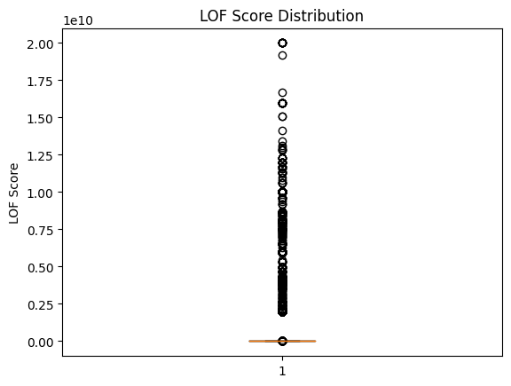

[output not shown]

```python
## Example input
# # Select numerical columns for LOF analysis (e.g., age, educational-num, hours-per-week)
print(df_income.head())
df_points = df_income[['age', 'educational-num','hours-per-week']]
# Convert to a list of tuples representing each data point
list_of_points = [tuple(x) for x in df_points.to_numpy()]
# list_of_points = [[0,0],[-1,0],[0,-1],[1,0],[5,5]]
# get_outliers(list_of_points,2,distance_approach="Manhattan") ==> [(5,5)]
outliers = get_outliers(list_of_points, K=5, distance_approach="Euclidean")
print("Detected outliers:", outliers)
```